# Heuristic tree pruning

```r
knitr::opts_chunk$set(echo = TRUE, warning = FALSE, message = FALSE)
# Set markdown knitting options

library(ggplot2)
library(cowplot)
library(ggtree)
library(phytools)
library(ggExtra)
library(readr)
library(here)
library(tidyr)
library(dplyr)
source("C:/bin/core/r/design.r")
source("C:/bin/core/r/get_tree_info.r")
#source("C:/Users/grt814/bin/core/corelib/design.r")
#source("C:/Users/grt814/bin/core/get_tree_info.r")
# Load required packages


tree_type = "astral"
cat(toupper(tree_type), "TREE\n\n")
```

```
## ASTRAL TREE
```

```r
# Print out tree type (passed from generator)
```

< Back to summary

# 1 Definitions

1. Pruning: Removing a branch from a tree
2. Paring: Pruning one of the two descending branches from a selected branch to increase its length/support

# 2 Tree paring algorithm

### 2.0.1 Setup:

1. Select a branch length percentile and support threshold.
2. Set a maximum number of iterations to perform and a maximum number of tips to remove in total. Also set a max number of tips to remove during any singly PRUNE.
3. Provide branches to be exempt from PRUNING.

### 2.0.2 Algorithm:

1. Identify branches with length below the selected quantile of all branches AND below the selected support level.
2. Of the two branches descending from this branch, select one to remove. Selection criteria could be:
   - Random, possibly with some sort of bootstrapping
   - Minimize species removed
   - Maximize support retained
   - Other?
3. Repeat until one of the stopping conditions are met:
   - No branches that fall below the selected percentile are also below the selected support level
   - The maximum number of iterations has been reached
   - The current iteration would result in more than the maximum allowed species to be removed

### 2.0.3 Notes:

1. Currently, only internal branches are considered since no support is assigned to the tips. But we could calculate support on the tips as number of genes in which they are present. However, ASTRAL trees also don’t have branch lengths on the tips, so it wouldn’t work for them anyways.
2. The branch length threshold is re-calculated each iteration.
3. The new branches inherit the support level from the retained clade. It is not currently recalculated.

# 3 Example output using the minimize species removed selection criterion

```r
infile = here("docs", "data", "trees", "paring", paste("min-spec-paring-", tree_type, "-exempt", sep=""), paste("min-spec-paring-", tree_type, "-exempt.log", sep=""))
# Path to the paring log file for the current tree type

in_data = read.csv(infile, header=T, sep="\t", comment.char="#")
# Read the data from the log file

exempt_branches = read.csv(here("docs", "data", "trees", "paring", paste(tree_type, "-exempt-branches.txt", sep="")), comment.char="#")
names(exempt_branches) = c("branch")

in_str = read_file(infile)
cat(in_str)
```

```
## # Tree pruning with heuristic metrics.
## # Version Beta 1.0 released on October 2021
## # pare was developed by Jeffrey Good, Gregg Thomas
## #
## # The date and time at the start is: 11.12.2021 | 13:45:53
## # Using Python version:              3.9.4
## #
## # The program was called as:         pare.py -t full_coding_iqtree_astral.cf.rooted.tree -o min-spec-paring-astral-exempt --overwrite -i 30 -e astral-exempt-branches.txt -g 50
## #
## # -----------------------------------------------------------------------------------------------------------------------------
## # INPUT/OUTPUT INFO:
## # Tree input type:                      file
## # Tree file                             full_coding_iqtree_astral.cf.rooted.tree
## # Output directory:                     min-spec-paring-astral-exempt
## # Log file:                             min-spec-paring-astral-exempt.log
## # -----------------------------------------------------------------------------------------------------------------------------
## # OPTIONS INFO:
## # Option                                Current setting               Current action
## # Branch length percentile (-b)         10                            Branches will be considered for paring each iteration if they fall below this percentile of all branch lengths.
## # Lower gCF threshold (-g)              50                            Branches will be considered for paring each iteration if they have a gCF lower than this.
## # Maximum iterations of paring (-i)     30                            The program will stop paring after this many iterations, regardless of other settings.
## # Total maximum tips to prune (-s)      Unlimited                     The program will stop paring after this tips have been pruned, regardless of other settings.
## # Maximum tips to prune per branch (-m) 10                            Branches selected to prune that have more than this many species descending will be retained.
## # -e                                    astral-exempt-branches.txt    pare will exempt the branches listed in this file from pruning.
## # --overwrite                           True                          pare will OVERWRITE the existing files in the specified output directory.
## # --quiet                               False                         Time, memory, and status info will be printed to the screen while pare is running.
## # -------------------------------------------------------------------------------------------------------------------------------------------------------------------------------
## # Date        Time      Current step                  Status                                                      Elapsed time (s)    Step time (s)   Current mem usage (MB)   Virtual mem usage (MB)
## # -------------------------------------------------------------------------------------------------------------------------------------------------------------------------------
## # 11.12.2021  13:45:53  Reading input file            Success: file read                                          0.50897             0.00184         24.35938                 5485.02344
## # 11.12.2021  13:45:54  Parsing input tree            Success: tree with 188 tips and 186 internal nodes read.    0.77805             0.26633         24.875                   5485.27344
## # INFO: Original tree with node labels:  ((Lophiomys_imhausi_UM5152,Lophuromys_woosnami_LSUMZ37793)<1>,(((Phloeomys_cumingi_FMNH198472,Phloeomys_pallidus_JEC43)<2>,((Crateromys_heaneyi_KU165014,Batomys_russatus_KU165776)<3>,(Carpomys_melanurus_FMNH198723,Musseromys_anacuao_FMNH209523)<4>)<5>)<6>,…
## # 11.12.2021  13:45:54  Reading exempt branches       Success: 13 branches will be exempt from paring.            0.79166             0.00726         24.875                   5485.27344
## # --------------------------------------------------
## # INFO: Branch <11> chosen for paring. Branch Sommeromys_macrorhinos_Z21740 will be pruned and remove 1 species
## # INFO: Branch <14> chosen for paring. Branch Melasmothrix_naso_Z21808 will be pruned and remove 1 species
## # INFO: Branch <28> chosen for paring. Branch rnor6 chosen for pruning, but is exempt. Switching to sister branch.
## # INFO: Branch <28> chosen for paring. Branch <27> will be pruned and remove 2 species
## # INFO: Branch <31> chosen for paring. Branch Rattus_leucopus_sample1 will be pruned and remove 1 species
## # INFO: Branch <33> chosen for paring. Branch Rattus_tunneyi_RAT130 will be pruned and remove 1 species
```

[output cut: 77 more lines]

```
## 4    0.24019608645   4   4   ((Lophiomys_imhausi_UM5152,Lophuromys_woosnami_LSUMZ37793)<1>_84.3:0.836628,(((Phloeomys_cumingi_FMNH198472,Phloeomys_pallidus_JEC43)<2>_93.9:2.674754292,((Crateromys_heaneyi_KU165014,Batomys_russatus_KU165776)<3>_82.1:1.4948862343,(Carpomys_melanurus_FMNH198723,Musse…
## 5    0.25123060776   2   4   ((Lophiomys_imhausi_UM5152,Lophuromys_woosnami_LSUMZ37793)<1>_84.3:0.836628,(((Phloeomys_cumingi_FMNH198472,Phloeomys_pallidus_JEC43)<2>_93.9:2.674754292,((Crateromys_heaneyi_KU165014,Batomys_russatus_KU165776)<3>_82.1:1.4948862343,(Carpomys_melanurus_FMNH198723,Musse…
## # 11.12.2021  13:46:05  Writing summary stats to log  Success                                                     11.92391            0.01807         25.56641                 5485.52344
## # ===============================================================================================================================================================================
## #
## # Done!
## #
## # Pared 40 total branches and removed 58 total tips.
## #
## # The date and time at the end is: 11.12.2021 | 13:46:05
## # Total execution time:            11.927 seconds.
## # Output directory for this run:   min-spec-paring-astral-exempt
## # Log file for this run:           min-spec-paring-astral-exempt/min-spec-paring-astral-exempt.log
## # ===============================================================================================================================================================================
## #
```

```r
# Read the whole logfile as raw text and print
```

# 4 Visualization of iterations using the minimize species removed selection criterion

## 4.1 Trees

```
## [1] "Iteration 0"
```

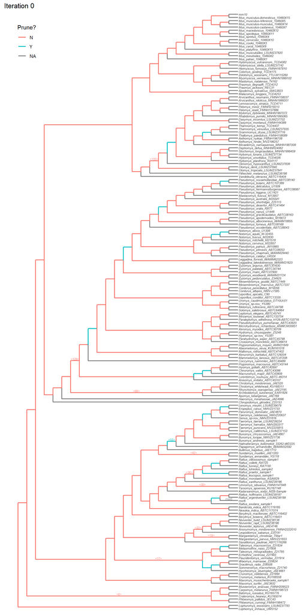

```
## [1] "Iteration 1"
```

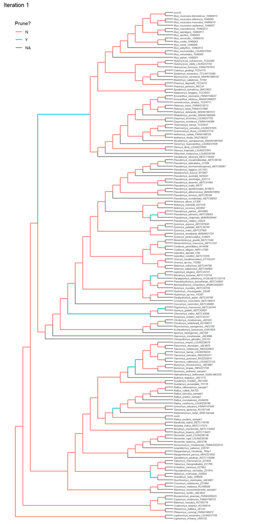

```
## [1] "Iteration 2"
```

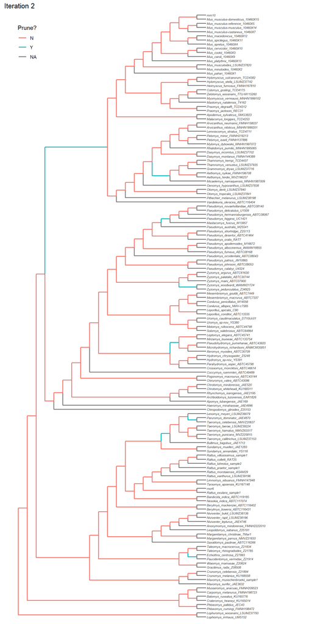

```
## [1] "Iteration 3"
```

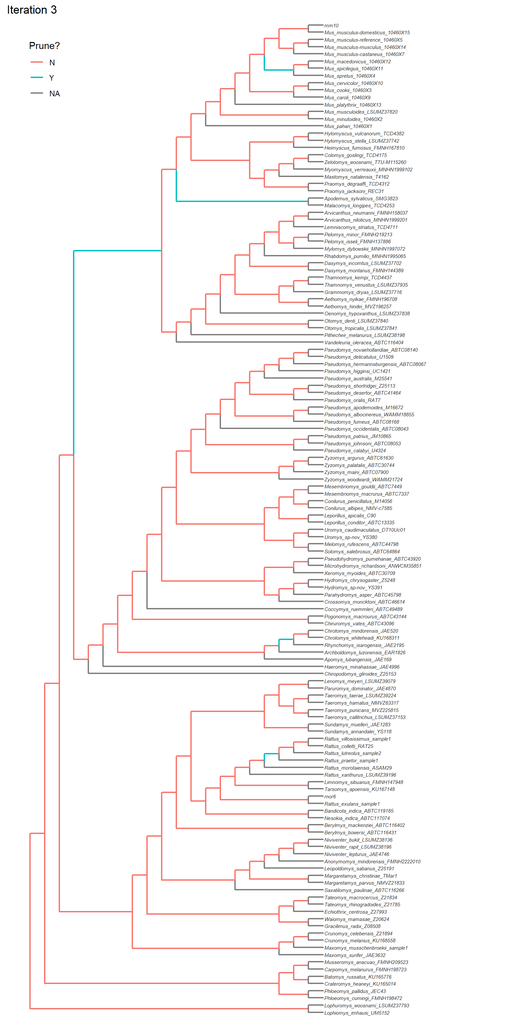

```
## [1] "Iteration 4"
```

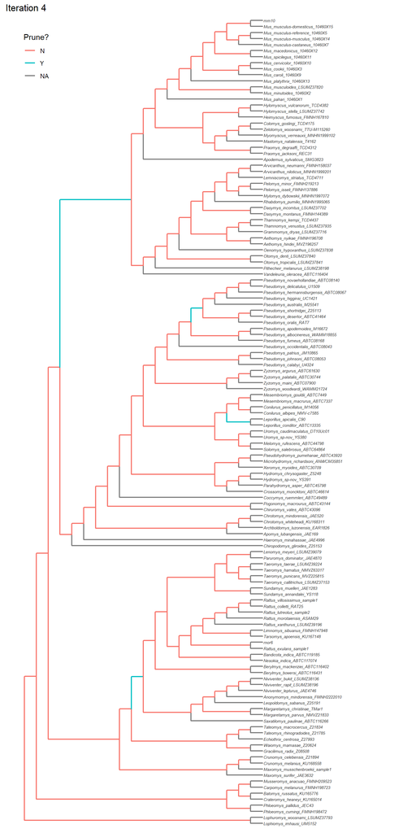

```
## [1] "Iteration 5"
```

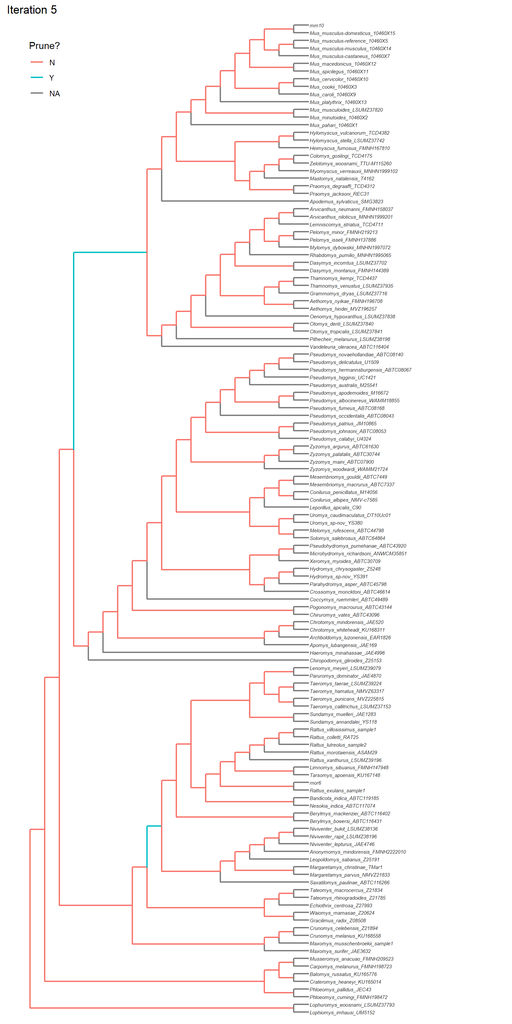

```r
plist = list()
tlist = list()
# Lists for figures per iteration

for(i in 1:nrow(in_data)){
# Loop over every pruning iteration in the input data

  print(paste("Iteration", i-1))

  iter_tree = read.tree(text=in_data[i,]$tree)
  # Read the tree into R

  tree_to_df_list = treeToDF(iter_tree)
  iter_tree_info = tree_to_df_list[["info"]]
  # Parse the tree to a data frame

  iter_tree_info = iter_tree_info %>%
                    filter(node.type == "internal") %>%
                    tidyr::separate(label, c("label","supp"), sep="_") %>%
                    bind_rows(filter(iter_tree_info, !node.type == "internal")) %>%
                    arrange(node)
  # Separates the node label from the support of the internal nodes

  #stop()

  bl_quant_10 = quantile(iter_tree_info$branch.length, 0.10, na.rm=T)
  gcf_thresh = 50
  scf_thresh = 40
  # Set the thresholds for pruning that were used

  iter_tree_info$supp = as.numeric(iter_tree_info$supp)
  # Convert the internal labels to numeric as the support values

  bl_gcf_p = ggplot(iter_tree_info, aes(x=branch.length, y=supp)) +
    geom_point(size=3, alpha=0.5) +
    geom_vline(xintercept=bl_quant_10, linetype="dashed", color=corecol(numcol=1, offset=6), size=1) +
    geom_hline(yintercept=gcf_thresh, linetype="dashed", color=corecol(numcol=1, offset=6), size=1) +
    xlab("Branch length") +
    ylab("gCF") +
    ggtitle(paste("Iteration", i-1)) +
    bartheme()
    if(tree_type=="concat"){
      bl_gcf_p = bl_gcf_p + scale_x_continuous(limits=c(0,0.035))
    }
  # Generate the plot of branch length vs. support

  bl_gcf_p = ggExtra::ggMarginal(bl_gcf_p, type="histogram", bins=50, fill=corecol(pal="wilke", numcol=1, offset=4), color="#666666")
  # Add the distributions to the plot

  plist[[i]] = bl_gcf_p
  # Save the plot to the list

  ##########

  iter_tree_info$low.b = ifelse(iter_tree_info$branch.length < bl_quant_10 & iter_tree_info$supp < gcf_thresh, "Y", "N")
  # Categorize each branch as being pruned or not

  if(tree_type == "astral"){
    xmax = 31
  }else if(tree_type == "concat"){
    xmax = 0.125
    iter_tree_info$low.b[iter_tree_info$node.type=='tip'] = "N"
  }
  # Set the max value for the x-axis in the tree figure based on the tree type

  b_tree = ggtree(iter_tree, size=0.8, ladderize=F, aes(color=iter_tree_info$low.b)) +
    scale_color_discrete(name = "Prune?") +
    xlim(0, xmax) +
    geom_tiplab(color="#333333", fontface='italic', size=2) +
    ggtitle(paste("Iteration", i-1)) +
    #geom_label(aes(x=branch, label=as.character(node), label.size=NA, fill="white")) +
    theme(legend.position=c(0.075,0.95))

  if(i==1){
    iter_tree_info$exempt = ifelse(iter_tree_info$label %in% exempt_branches$branch, "Y", "N")
    b_tree = b_tree + geom_text(aes(x=branch, label=ifelse(iter_tree_info$label %in% exempt_branches$branch, as.character(iter_tree_info$label), "")), size=2, vjust=-0.3, show.legend=F)
  }
  # Add the exempt branches as labels for the first iteration

  print(b_tree)
  #tlist[[i]] = b_tree
  # Generate and print the tree figure for the current iteration
}
```

## 4.2 Branch length and gCF distributions

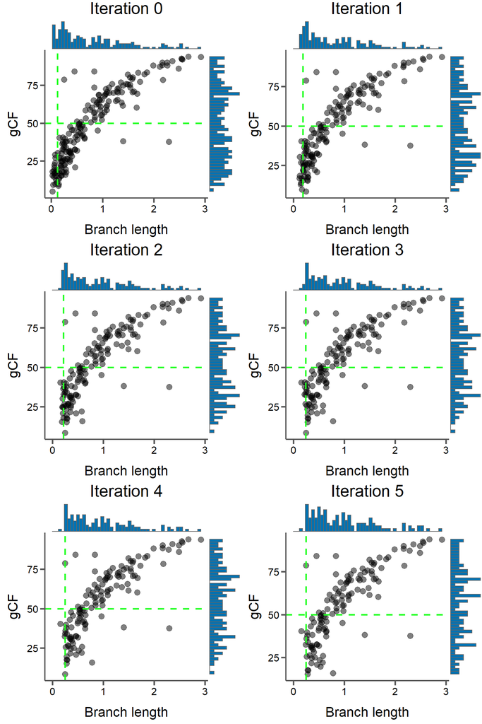

```r
p = plot_grid(plotlist=plist, ncol=2)
print(p)
```

```r
# Combine the bl and support figures and print
```